# Creating images with R

Felix Tasker-Erceg

```css
body {
  font-family: "Times New Roman";
  color: white;
  background-color: #6b422b;
}
```

## Project requirements

To meet the requirements regarding GitHub, I wrote about *why* I chose this course as well as important information that someone may want to know about the course.

This important information includes:

- Link to course outline.
- Percentage obtained from each task within the course.
- Capabilities developed within the course.
- A short blurb explaining the purpose of the repo.

I carefully followed the criteria of the assignment, making sure to hit the key points I have to use as well as personal touch and creativity. I struggled with timing but it led to me making a final product that is much better than I originally created. I used a already existing meme based on a statistical joke and improved on it considerably.

**My Website (profile) link:** https://github.com/felixtaskererceg

**Link to repo:** https://github.com/felixtaskererceg/STATS220

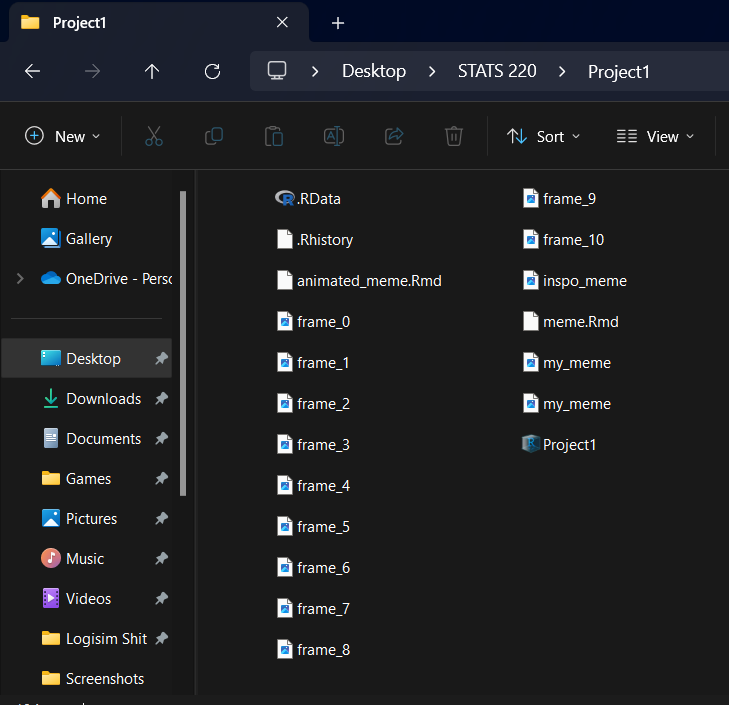

Screenshot of Folder

[figure not shown]

Inspo Meme

## My meme

[figure not shown]

```r
library(magick)

#I have selected a statistics meme that uses wordplay and the film Mean Girls.

#First Image
mean_girl_on_phone <- image_read("frame_0.gif") %>%
  image_scale(500)

#Square adjacent first image
meme_text1 <- image_blank(width = 300,
                          height = 280,
                          color = "#FF69B4") %>%
  image_annotate(text = "Average people \n can...",
                 color = "#FFFFFF",
                 size = 40,
                 font = "Impact",
                 gravity = "Center")

#Second Image
mean_girl_off_phone <- image_read("frame_10.gif") %>%
  image_scale(500)

#Square adjacent to second image
meme_text2 <- image_blank(width = 300,
                          height = 280,
                          color = "#FF69B4") %>%
  image_annotate(text = "...often be mean.",
                 color = "#FFFFFF",
                 size = 40,
                 font = "Impact",
                 gravity = "Center") %>%
  image_annotate(text = "Get it? Because average is the mean... and mean girls... (raucous laughter)",
                 color = "#FFFFFF",
                 size = 9,
                 font = "Impact",
                 gravity = "SouthEast")

#joining top row
top_row <- image_append(c(mean_girl_on_phone, meme_text1))

#joining bottom row
bottom_row <- image_append(c(mean_girl_off_phone, meme_text2))

#create vector
meme_vector <- c(top_row, bottom_row)

#join both rows
image_append(meme_vector, stack = TRUE)
```

```r
# creating each frame, where the text comes from the counts vector an appears both below and above on each image using pipes
frame0 <- image_read("frame_0.gif") %>%
  image_annotate(text = "AVERAGE PEOPLE CAN", size = 50, gravity = "North", color = "#FF69B4") %>%
  image_annotate(text = "OFTEN BE MEAN...", size = 50, gravity = "South", color = "#FF69B4")

frame1 <- image_read("frame_1.gif") %>%
  image_annotate(text = "AVERAGE PEOPLE CAN", size = 50, gravity = "North", color = "#FF69B4") %>%
  image_annotate(text = "OFTEN BE MEAN...", size = 50, gravity = "South", color = "#FFFFFF")

frame2 <- image_read("frame_2.gif") %>%
  image_annotate(text = "AVERAGE PEOPLE CAN", size = 50, gravity = "North", color = "#FF69B4") %>%
  image_annotate(text = "OFTEN BE MEAN...", size = 50, gravity = "South", color = "#FFFFFF")

frame3 <- image_read("frame_3.gif") %>%
  image_annotate(text = "AVERAGE PEOPLE CAN", size = 50, gravity = "North", color = "#FF69B4") %>%
  image_annotate(text = "OFTEN BE MEAN...", size = 50, gravity = "South", color = "#FF69B4")

frame4 <- image_read("frame_4.gif") %>%
  image_annotate(text = "AVERAGE PEOPLE CAN", size = 50, gravity = "North", color = "#FF69B4") %>%
  image_annotate(text = "OFTEN BE MEAN...", size = 50, gravity = "South", color = "#FF69B4")

frame5 <- image_read("frame_5.gif") %>%
  image_annotate(text = "AVERAGE PEOPLE CAN", size = 50, gravity = "North", color = "#FF69B4") %>%
  image_annotate(text = "OFTEN BE MEAN...", size = 50, gravity = "South", color = "#FFFFFF")

frame6 <- image_read("frame_6.gif") %>%
  image_annotate(text = "AVERAGE PEOPLE CAN", size = 50, gravity = "North", color = "#FF69B4") %>%
  image_annotate(text = "OFTEN BE MEAN...", size = 50, gravity = "South", color = "#FFFFFF")

frame7 <- image_read("frame_7.gif") %>%
  image_annotate(text = "AVERAGE PEOPLE CAN", size = 50, gravity = "North", color = "#FF69B4") %>%
  image_annotate(text = "OFTEN BE MEAN...", size = 50, gravity = "South", color = "#FF69B4")

frame8 <- image_read("frame_8.gif") %>%
  image_annotate(text = "AVERAGE PEOPLE CAN", size = 50, gravity = "North", color = "#FF69B4") %>%
  image_annotate(text = "OFTEN BE MEAN...", size = 50, gravity = "South", color = "#FF69B4")

frame9 <- image_read("frame_9.gif") %>%
  image_annotate(text = "AVERAGE PEOPLE CAN", size = 50, gravity = "North", color = "#FF69B4") %>%
  image_annotate(text = "OFTEN BE MEAN...", size = 50, gravity = "South", color = "#FFFFFF")

frame10 <- image_read("frame_10.gif") %>%
  image_annotate(text = "AVERAGE PEOPLE CAN", size = 50, gravity = "North", color = "#FF69B4") %>%
  image_annotate(text = "OFTEN BE MEAN...", size = 50, gravity = "South", color = "#FFFFFF")

# putting the frames in order using a vector
frames <- c(frame0, frame1, frame2, frame3, frame4, frame5, frame6, frame7, frame8, frame9, frame10)

# creating an animation
image_animate(frames, fps = 5)
```

## Creativity

[figure not shown]

meme_gif

For creativity, I wanted to explore the effects and possible applications of the animation function in the magick package.

To do this I first experimented will alternating the colors of the text in the meme. However, this change to no create the effect I desired. To account for this I upped the amount of frames I had from 4 to 11, to give me more room to work with on the gif. Ultimately I felt that changing the colors too much was not pleasing to eye. So I returned the color change back to a simple flip between white and hot-pink on every second frame.

The added benefit of this change though was I got to more smoothly demonstrate the expression of the “mean girl” in the gif. This made for a much better effect in my opinion.

Another creative factor I employed was the clean use of sub-headings and emojis in the GitHub page.

## Learning reflection

The important ideas I learned from this initial section of STATS 220 are actually more organisational and assumptive learnings that I have taken away.

I made the intense initial error of assuming my prior knowledge of code would help me complete the project in a shorter planned time. However, as I biased other assignment due to this self imposed false confidence - I left it too late and drastically underestimated my skill set in a different language.

Besides that… I really enjoyed working with images in a coding language. It is something completely new to me and seems like such a valid and useful skill.